# hw3

yang an

2025-02-15

```r
rm(list = ls())
```

```r
# Load necessary libraries
library(ggplot2)

# Load the data
data <- read.csv("rate_lung_cancer_with_smoking.csv")
```

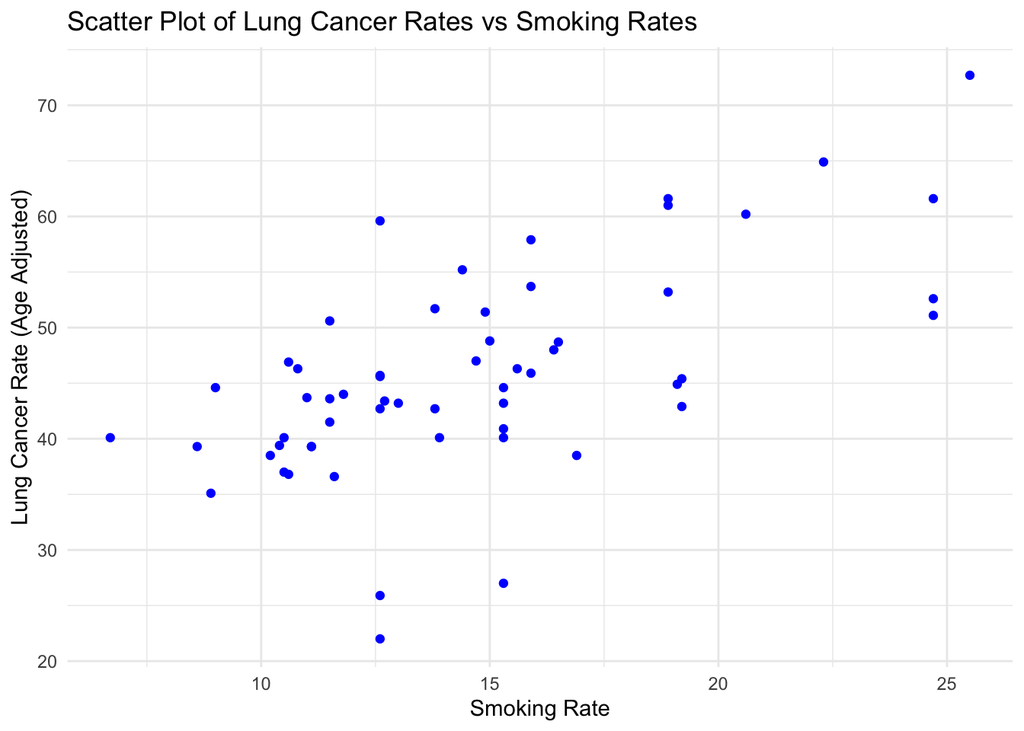

```r
# 1. Scatter plot and correlation
ggplot(data, aes(x = Smoking_Rate, y = Age_Adjusted_Rate)) +
  geom_point(color = "blue") +
  ggtitle("Scatter Plot of Lung Cancer Rates vs Smoking Rates") +
  xlab("Smoking Rate") +
  ylab("Lung Cancer Rate (Age Adjusted)") +
  theme_minimal()
```

```r
# Calculate correlation
correlation <- cor(data$Smoking_Rate, data$Age_Adjusted_Rate)
print(paste("Correlation:", correlation))
```

```
## [1] "Correlation: 0.622157339478121"
```

1.Scatter Plot and Correlation:

The scatter plot of lung cancer rates against smoking rates has been displayed. The correlation between smoking rates and lung cancer rates is 0.622, indicating a moderate positive relationship.

```r
# 2. Fit linear regression model
model <- lm(Age_Adjusted_Rate ~ Smoking_Rate, data = data)
summary_model <- summary(model)
print(summary_model)
```

```
##
## Call:
## lm(formula = Age_Adjusted_Rate ~ Smoking_Rate, data = data)
##
## Residuals:
##      Min       1Q   Median       3Q      Max
## -21.0928  -3.4639  -0.1371   5.1453  16.5072
##
## Coefficients:
##              Estimate Std. Error t value Pr(>|t|)
## (Intercept)   26.1161     3.4429   7.586 3.73e-10 ***
## Smoking_Rate   1.3474     0.2266   5.947 1.85e-07 ***
## ---
## Signif. codes:  0 '***' 0.001 '**' 0.01 '*' 0.05 '.' 0.1 ' ' 1
##
## Residual standard error: 7.354 on 56 degrees of freedom
## Multiple R-squared:  0.3871, Adjusted R-squared:  0.3761
## F-statistic: 35.37 on 1 and 56 DF,  p-value: 1.854e-07
```

2. Linear Regression Model (Y = β0 + β1*X + error):

The estimated intercept (β0): 26.12 The estimated slope (β1): 1.35 The model equation is: Age_Adjusted_Rate = 26.12 + 1.35*Smoking_Rate + error

```r
# 3. Extract estimates and confidence intervals
intercept <- coef(model)[1]
slope <- coef(model)[2]
conf_int <- confint(model, level = 0.95)

print(paste("Intercept Estimate:", round(intercept, 3)))
```

```
## [1] "Intercept Estimate: 26.116"
```

```r
print(paste("Slope Estimate:", round(slope, 3)))
```

```
## [1] "Slope Estimate: 1.347"
```

```r
print("95% Confidence Intervals:")
```

```
## [1] "95% Confidence Intervals:"
```

```r
print(conf_int)
```

```
##                   2.5 %    97.5 %
## (Intercept)  19.2191638 33.013042
## Smoking_Rate  0.8934968  1.801222
```

```r
# Statistical significance assessment
p_value_slope <- summary_model$coefficients["Smoking_Rate", "Pr(>|t|)"]
print(paste("P-value for the slope (Smoking_Rate):", p_value_slope))
```

```
## [1] "P-value for the slope (Smoking_Rate): 1.85419476931132e-07"
```

```r
if ((conf_int["Smoking_Rate", 1] > 0 | conf_int["Smoking_Rate", 2] < 0) && p_value_slope < 0.05) {
  print("The slope (Smoking_Rate) is statistically significant because its 95% confidence interval does NOT contain zero AND p-value < 0.05.")
} else {
  print("The slope (Smoking_Rate) is NOT statistically significant because its 95% confidence interval contains zero OR p-value ≥ 0.05.")
}
```

```
## [1] "The slope (Smoking_Rate) is statistically significant because its 95% confidence interval does NOT contain zero AND p-value < 0.05."
```

3.95% Confidence Intervals:

Intercept (β0): [19.22, 33.01] Slope (β1): [0.89, 1.80]

The impact of smoking rates on lung cancer rates in California counties statistically significant, since its 95% confidence interval does not contain zero and p-value is 1.85419476931132e-07< 0.05.

4.The impact of smoking rates on lung cancer rates in California counties statistically significant, since its 95% confidence interval does not contain zero and p-value < 0.05.

```r
# 5. Extract the estimate of the residual variance (sigma^2)
sigma_squared <- summary_model$sigma^2
print(paste("Residual Variance Estimate (sigma^2):", round(sigma_squared, 3)))
```

```
## [1] "Residual Variance Estimate (sigma^2): 54.078"
```

```r
# Calculate the 95% confidence interval for the residual variance
# Using the chi-square distribution to find the confidence bounds
n <- length(data$Smoking_Rate)  # Sample size
df_residual <- n - 2  # Degrees of freedom (number of observations - number of parameters)

# Compute the confidence interval using chi-square quantiles
alpha <- 0.05  # 95% confidence level
lower_bound <- sigma_squared * df_residual / qchisq(1 - alpha/2, df_residual)
upper_bound <- sigma_squared * df_residual / qchisq(alpha/2, df_residual)

print(paste("95% Confidence Interval for Residual Variance: [",
            round(lower_bound, 3), ", ", round(upper_bound, 3), "]"))
```

```
## [1] "95% Confidence Interval for Residual Variance: [ 38.545 ,  81.382 ]"
```

5.Residual Variance Estimate and Confidence Interval:

The residual variance estimate (σ²): 54.08 The estimated 95% confidence interval for residual variance: [38.545 , 81.382]